# KKTC'de Asgari Ücret ve Enflasyon Dinamikleri: 2022 Yapısal Kırılma Hipotezi ve Rejim Değişikliği

## 2. Kayan Pencere Regresyonu (Rolling OLS)

Zaman serilerinde katsayıların statik kalmadığını ölçmek için 3 yıllık (36 aylık) bir yuvarlanan OLS modeli kurulmuştur.

Bu metodoloji, asgari ücretin (maliyet şoku) enflasyona geçişkenliğinin zaman içindeki değişimini görselleştirerek; TÜFE'nin "Ücret Fiyat Sarmalı" (Tüleykan, 2019) baskısında mı kaldığını, yoksa farklı bir rejime mi girdiğini görmemizi sağlar.

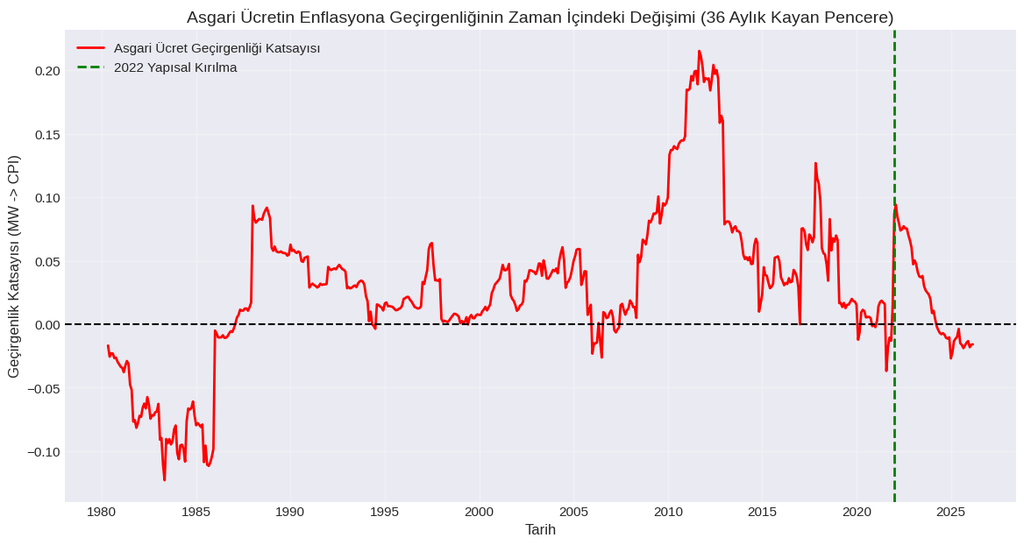

```python
window_size = 36 # 3 yıllık hareketli pencere

# Sabit Terim ekleniyor
exog_roll = sm.add_constant(df[['mw_growth', 'usdtry_growth']])
roll_model = RollingOLS(df['inflation'], exog_roll, window=window_size).fit()

plt.figure(figsize=(14, 7))
plt.plot(df['Date'], roll_model.params['mw_growth'], label='Asgari Ücret Geçirgenliği Katsayısı', color='red', linewidth=2)
plt.axhline(y=0, color='black', linestyle='--')
plt.axvline(x=pd.to_datetime('2022-01-01'), color='green', linestyle='--', linewidth=2, label='2022 Yapısal Kırılma')
plt.title('Asgari Ücretin Enflasyona Geçirgenliğinin Zaman İçindeki Değişimi (36 Aylık Kayan Pencere)', fontsize=14)
plt.ylabel('Geçirgenlik Katsayısı (MW -> CPI)')
plt.xlabel('Tarih')
plt.legend()
plt.grid(True, alpha=0.3)
plt.show()
```

## 3. Yapısal Kırılma ve Etkileşim Modeli (Chow Test Mantığı)

Aşağıdaki model, Otokorelasyon ve Değişen Varyans sorununa karşı Dirençli Standart Hatalar (HAC) kullanılarak tahmin edilmiştir.

**Hipotez:** H0: 2022 öncesi ve sonrası asgari ücretin (ve kurun) enflasyona etkisi aynıdır.

Modelde, serilerdeki içsel dinamikleri yakalamak adına, enflasyonun, kurun ve asgari ücretin birinci gecikmeleri (`_L1`) de bağımsız değişken olarak eklenmiştir.

```python
# Gecikmeli terimlerin modele dahil edilmesi
df['inflation_lag1'] = df['inflation'].shift(1)
df['MW_x_Post2022_L1'] = df['MW_x_Post2022'].shift(1)
df['mw_growth_L1'] = df['mw_growth'].shift(1)
df['usdtry_growth_L1'] = df['usdtry_growth'].shift(1)
df['USD_x_Post2022_L1'] = df['USD_x_Post2022'].shift(1)

df_reg = df.dropna()

# Bağımsız ve Bağımlı değişkenlerin atanması
X_struct = df_reg[['inflation_lag1', 'mw_growth', 'mw_growth_L1', 'MW_x_Post2022', 'MW_x_Post2022_L1',
                   'usdtry_growth', 'usdtry_growth_L1', 'USD_x_Post2022', 'USD_x_Post2022_L1']]
X_struct = sm.add_constant(X_struct)
y_struct = df_reg['inflation']

# Otokorelasyona ve değişen varyansa karşı dirençli tahminci (HAC)
struct_model = sm.OLS(y_struct, X_struct).fit(cov_type='HAC', cov_kwds={'maxlags':3})

print(struct_model.summary())
```

```
                            OLS Regression Results
==============================================================================
Dep. Variable:              inflation   R-squared:                       0.422
Model:                            OLS   Adj. R-squared:                  0.413
Method:                 Least Squares   F-statistic:                     40.82
Date:                Mon, 20 Apr 2026   Prob (F-statistic):           2.76e-56
Time:                        11:13:17   Log-Likelihood:                -1314.7
No. Observations:                 585   AIC:                             2649.
Df Residuals:                     575   BIC:                             2693.
Df Model:                           9
Covariance Type:                  HAC
=====================================================================================
                        coef    std err          z      P>|z|      [0.025      0.975]
-------------------------------------------------------------------------------------
const                 0.9977      0.155      6.431      0.000       0.694       1.302
inflation_lag1        0.3082      0.040      7.636      0.000       0.229       0.387
mw_growth             0.0310      0.013      2.323      0.020       0.005       0.057
mw_growth_L1          0.0402      0.009      4.314      0.000       0.022       0.058
MW_x_Post2022        -0.0587      0.018     -3.335      0.001      -0.093      -0.024
MW_x_Post2022_L1      0.0059      0.025      0.236      0.813      -0.043       0.055
usdtry_growth         0.2067      0.030      6.955      0.000       0.148       0.265
usdtry_growth_L1      0.0692      0.059      1.177      0.239      -0.046       0.184
USD_x_Post2022        0.3985      0.110      3.611      0.000       0.182       0.615
USD_x_Post2022_L1    -0.0575      0.089     -0.649      0.517      -0.231       0.116
==============================================================================
Omnibus:                      258.280   Durbin-Watson:                   2.134
Prob(Omnibus):                  0.000   Jarque-Bera (JB):             3019.222
Skew:                           1.624   Prob(JB):                         0.00
Kurtosis:                      13.645   Cond. No.                         17.2
==============================================================================

Notes:
[1] Standard Errors are heteroscedasticity and autocorrelation robust (HAC) using 3 lags and without small sample correction
```